# Actividad 1.11A Series de tiempo

Rey Iván De La Fuente Chávez

2026-09-07

## 1. Datos de ventas

Se tienen ventas trimestrales de televisores durante cuatro años, expresadas en miles.

```r
ventas <- c(4.8, 4.1, 6.0, 6.5,
            5.8, 5.2, 6.8, 7.4,
            6.0, 5.6, 7.5, 7.8,
            6.3, 5.9, 8.0, 8.4)

tiempo <- 1:16
ventas_ts <- ts(ventas, start = c(1, 1), frequency = 4)

ventas_ts
```

```
##   Qtr1 Qtr2 Qtr3 Qtr4
## 1  4.8  4.1  6.0  6.5
## 2  5.8  5.2  6.8  7.4
## 3  6.0  5.6  7.5  7.8
## 4  6.3  5.9  8.0  8.4
```

## 2. Tendencia y estacionalidad

### Serie de tiempo

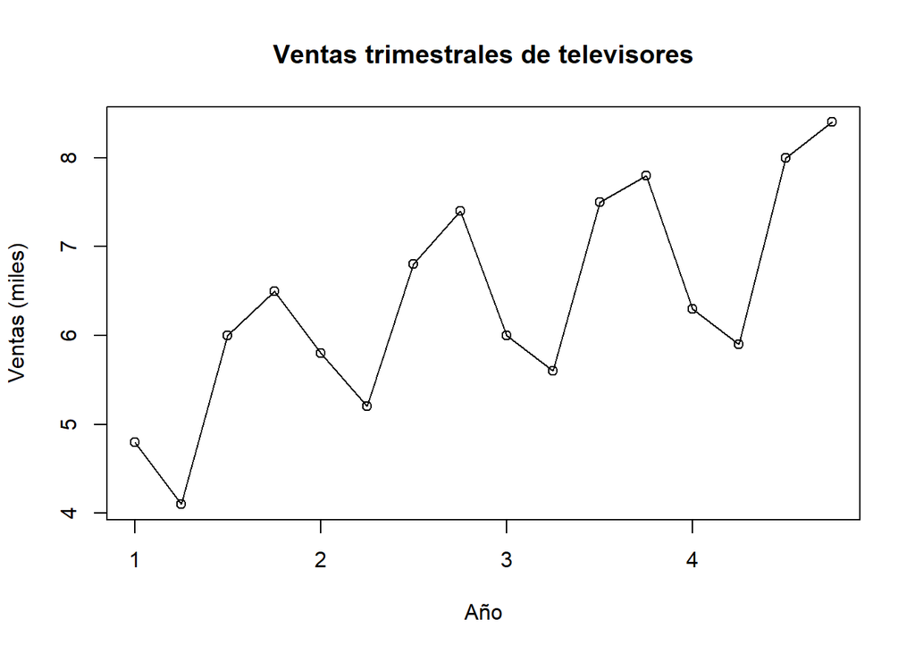

```r
plot(ventas_ts,
     type = "o",
     xlab = "Año",
     ylab = "Ventas (miles)",
     main = "Ventas trimestrales de televisores")
```

La serie no parece estacionaria, ya que las ventas presentan una tendencia general creciente y un patrón que se repite entre los trimestres.

### Autocorrelación

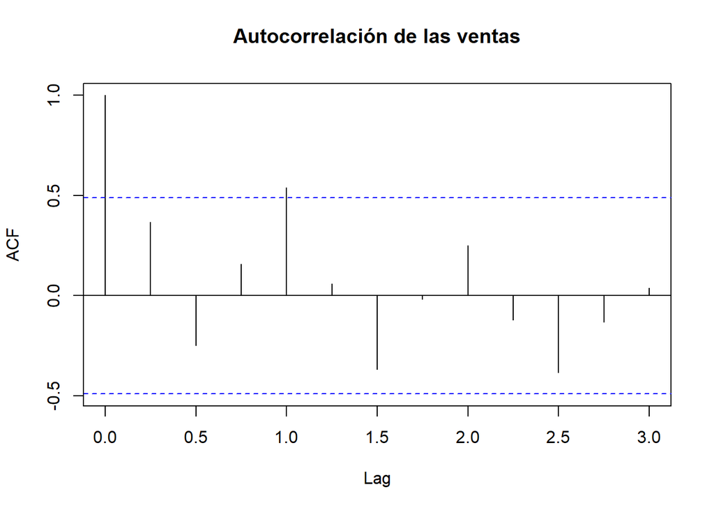

```r
acf(ventas_ts,
    lag.max = 12,
    main = "Autocorrelación de las ventas")
```

La gráfica de autocorrelación permitirá verificar si existe dependencia entre las observaciones separadas por distintos rezagos, especialmente en rezagos asociados con la frecuencia trimestral.

### Modelos aditivo y multiplicativo

Se prueban las dos formas de descomposición para posteriormente comparar cuál representa mejor la serie.

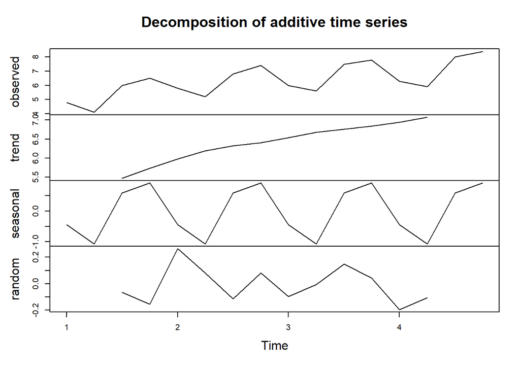

```r
descomp_add <- decompose(ventas_ts, type = "additive")
descomp_mult <- decompose(ventas_ts, type = "multiplicative")

plot(descomp_add)
```

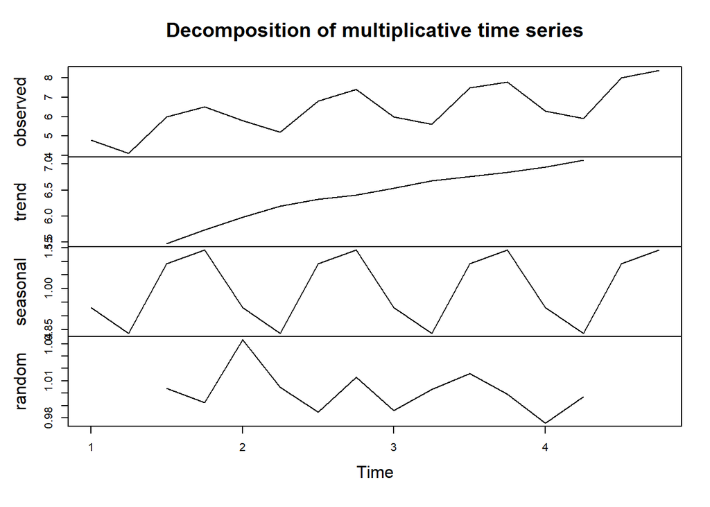

```r
plot(descomp_mult)
```

## 3. Índices estacionales y serie desestacionalizada

```r
indice_add <- tapply(descomp_add$seasonal,
                     cycle(ventas_ts),
                     mean,
                     na.rm = TRUE)

indice_mult <- tapply(descomp_mult$seasonal,
                      cycle(ventas_ts),
                      mean,
                      na.rm = TRUE)

indices <- data.frame(
  Trimestre = 1:4,
  Aditivo = as.numeric(indice_add),
  Multiplicativo = as.numeric(indice_mult)
)

round(indices, 4)
```

```
##   Trimestre Aditivo Multiplicativo
## 1         1 -0.4396         0.9307
## 2         2 -1.0688         0.8364
## 3         3  0.5896         1.0915
## 4         4  0.9187         1.1414
```

En el modelo aditivo, un índice positivo representa ventas por encima de la tendencia y uno negativo ventas por debajo. En el multiplicativo, valores mayores que 1 aumentan el nivel esperado y valores menores que 1 lo reducen.

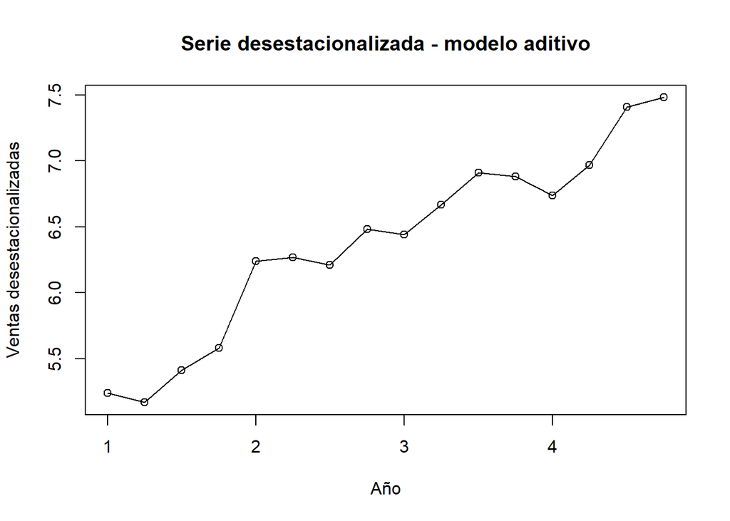

```r
estacional_add <- indice_add[cycle(ventas_ts)]
estacional_mult <- indice_mult[cycle(ventas_ts)]

ventas_des_add <- ventas_ts - estacional_add
ventas_des_mult <- ventas_ts / estacional_mult

plot(ventas_des_add,
     type = "o",
     xlab = "Año",
     ylab = "Ventas desestacionalizadas",
     main = "Serie desestacionalizada - modelo aditivo")
```

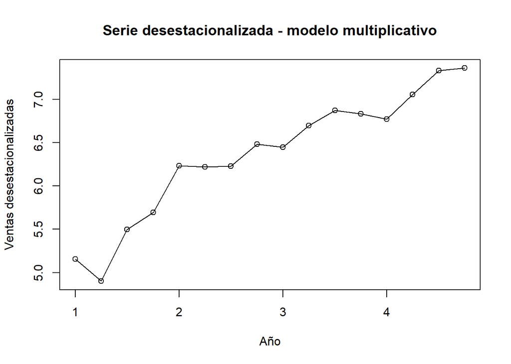

```r
plot(ventas_des_mult,
     type = "o",
     xlab = "Año",
     ylab = "Ventas desestacionalizadas",
     main = "Serie desestacionalizada - modelo multiplicativo")
```

## 4. Modelo lineal de tendencia

Se ajustan modelos lineales sobre las ventas desestacionalizadas. El modelo multiplicativo se analiza con mayor detalle y después se comparará con los demás mediante sus errores de predicción.

```r
modelo_lineal_add <- lm(as.numeric(ventas_des_add) ~ tiempo)
modelo_lineal_mult <- lm(as.numeric(ventas_des_mult) ~ tiempo)

summary(modelo_lineal_mult)
```

```
##
## Call:
## lm(formula = as.numeric(ventas_des_mult) ~ tiempo)
##
## Residuals:
##     Min      1Q  Median      3Q     Max
## -0.5007 -0.1001  0.0037  0.1207  0.3872
##
## Coefficients:
##             Estimate Std. Error t value Pr(>|t|)
## (Intercept)  5.10804    0.11171   45.73  < 2e-16 ***
## tiempo       0.14738    0.01155   12.76 4.25e-09 ***
## ---
## Signif. codes:  0 '***' 0.001 '**' 0.01 '*' 0.05 '.' 0.1 ' ' 1
##
## Residual standard error: 0.213 on 14 degrees of freedom
## Multiple R-squared:  0.9208, Adjusted R-squared:  0.9151
## F-statistic: 162.7 on 1 and 14 DF,  p-value: 4.248e-09
```

El resumen del modelo permite evaluar la significancia individual del coeficiente de tiempo mediante su prueba t y la significancia global mediante la prueba F.

### Análisis de residuos

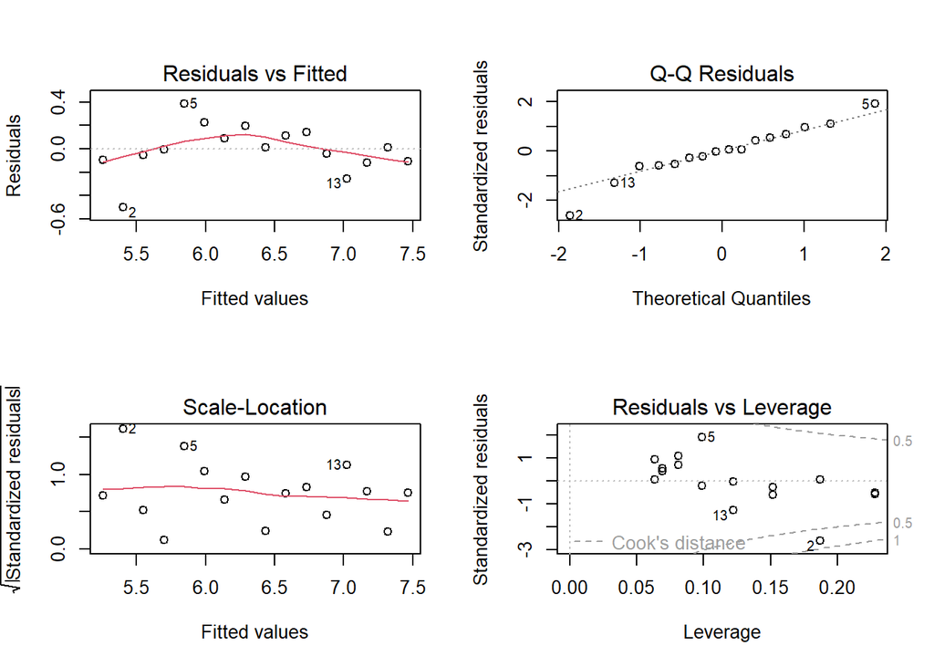

```r
par(mfrow = c(2, 2))
plot(modelo_lineal_mult)
```

```r
par(mfrow = c(1, 1))

shapiro.test(residuals(modelo_lineal_mult))
```

```
##
##  Shapiro-Wilk normality test
##
## data:  residuals(modelo_lineal_mult)
## W = 0.96379, p-value = 0.7307
```

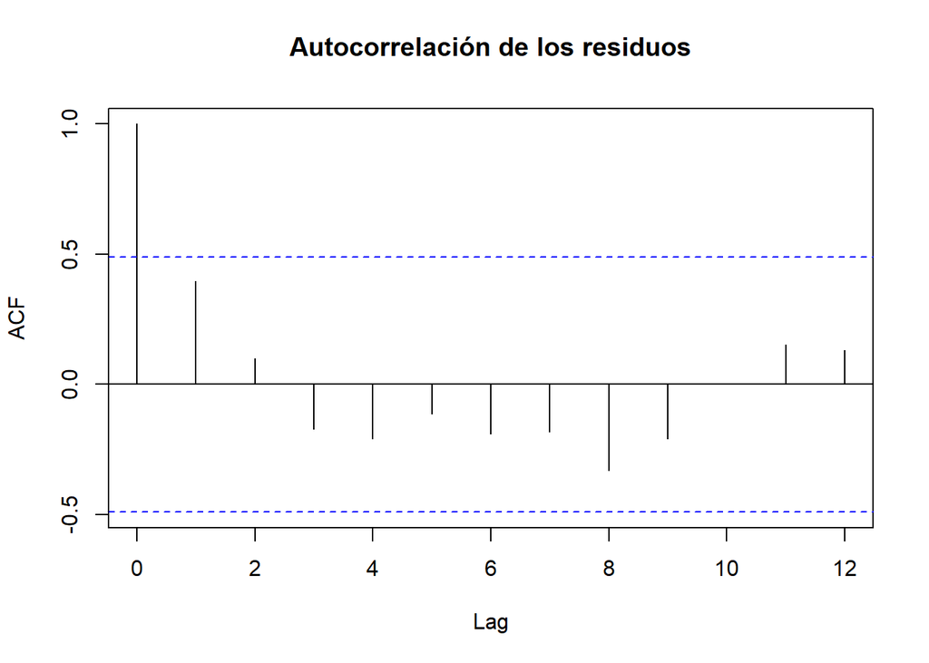

```r
acf(residuals(modelo_lineal_mult),
    main = "Autocorrelación de los residuos")
```

## 5. Modelo cuadrático

Se agrega el término cuadrático del tiempo para explorar una tendencia no lineal.

```r
tiempo2 <- tiempo^2

modelo_cuad_mult <- lm(as.numeric(ventas_des_mult) ~ tiempo + tiempo2)
summary(modelo_cuad_mult)
```

```
##
## Call:
## lm(formula = as.numeric(ventas_des_mult) ~ tiempo + tiempo2)
##
## Residuals:
##      Min       1Q   Median       3Q      Max
## -0.36986 -0.07058 -0.00100  0.11345  0.33110
##
## Coefficients:
##              Estimate Std. Error t value Pr(>|t|)
## (Intercept)  4.790283   0.152429  31.426 1.20e-13 ***
## tiempo       0.253302   0.041269   6.138 3.56e-05 ***
## tiempo2     -0.006231   0.002360  -2.640   0.0204 *
## ---
## Signif. codes:  0 '***' 0.001 '**' 0.01 '*' 0.05 '.' 0.1 ' ' 1
##
## Residual standard error: 0.1784 on 13 degrees of freedom
## Multiple R-squared:  0.9484, Adjusted R-squared:  0.9405
## F-statistic: 119.6 on 2 and 13 DF,  p-value: 4.268e-09
```

## 6. CME y EPAM

Se comparan tres modelos: lineal aditivo, lineal multiplicativo y cuadrático multiplicativo.

```r
pred_add_lin <- fitted(modelo_lineal_add) + estacional_add
pred_mult_lin <- fitted(modelo_lineal_mult) * estacional_mult
pred_mult_cuad <- fitted(modelo_cuad_mult) * estacional_mult

metricas <- function(real, pred) {
  c(
    CME = mean((real - pred)^2, na.rm = TRUE),
    EPAM = mean(abs((real - pred) / real), na.rm = TRUE) * 100
  )
}

comparacion <- rbind(
  "Aditivo lineal" = metricas(ventas, pred_add_lin),
  "Multiplicativo lineal" = metricas(ventas, pred_mult_lin),
  "Multiplicativo cuadrático" = metricas(ventas, pred_mult_cuad)
)

round(comparacion, 4)
```

```
##                              CME   EPAM
## Aditivo lineal            0.0329 2.4921
## Multiplicativo lineal     0.0330 2.4395
## Multiplicativo cuadrático 0.0219 1.9493
```

El mejor modelo será el que presente los valores más bajos de CME y EPAM.

```r
mejor_CME <- rownames(comparacion)[which.min(comparacion[, "CME"])]
mejor_EPAM <- rownames(comparacion)[which.min(comparacion[, "EPAM"])]

cat("Menor CME:", mejor_CME, "\n")
```

```
## Menor CME: Multiplicativo cuadrático
```

```r
cat("Menor EPAM:", mejor_EPAM, "\n")
```

```
## Menor EPAM: Multiplicativo cuadrático
```

## 7. Pronóstico del siguiente año

Se calculan los pronósticos de los cuatro trimestres del año 5 para los tres modelos analizados.

```r
futuro <- data.frame(
  tiempo = 17:20,
  tiempo2 = (17:20)^2
)

est_add_fut <- as.numeric(indice_add[1:4])
est_mult_fut <- as.numeric(indice_mult[1:4])

pron_add_lin <- predict(modelo_lineal_add, newdata = futuro) + est_add_fut
pron_mult_lin <- predict(modelo_lineal_mult, newdata = futuro) * est_mult_fut
pron_mult_cuad <- predict(modelo_cuad_mult, newdata = futuro) * est_mult_fut

pronosticos <- data.frame(
  Año = rep(5, 4),
  Trimestre = 1:4,
  Aditivo_lineal = pron_add_lin,
  Multiplicativo_lineal = pron_mult_lin,
  Multiplicativo_cuadratico = pron_mult_cuad
)

round(pronosticos, 3)
```

```
##   Año Trimestre Aditivo_lineal Multiplicativo_lineal Multiplicativo_cuadratico
## 1   5         1          7.184                 7.086                     6.790
## 2   5         2          6.701                 6.491                     6.131
## 3   5         3          8.505                 8.632                     8.027
## 4   5         4          8.980                 9.195                     8.406
```

### Gráfica final

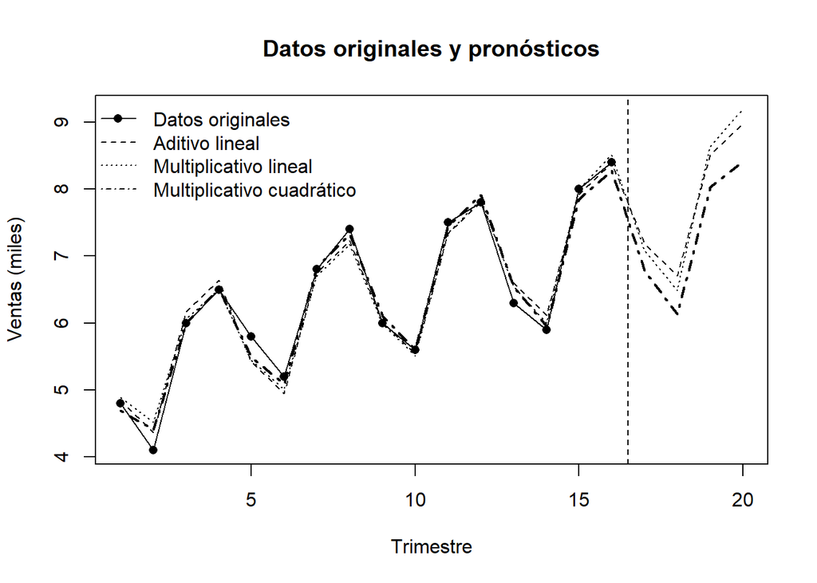

```r
tiempo_total <- 1:20
ventas_total <- c(ventas, rep(NA, 4))

serie_add_lin <- c(pred_add_lin, pron_add_lin)
serie_mult_lin <- c(pred_mult_lin, pron_mult_lin)
serie_mult_cuad <- c(pred_mult_cuad, pron_mult_cuad)

plot(tiempo_total, ventas_total,
     type = "o",
     pch = 16,
     xlab = "Trimestre",
     ylab = "Ventas (miles)",
     main = "Datos originales y pronósticos",
     ylim = range(c(ventas, serie_add_lin,
                    serie_mult_lin, serie_mult_cuad)))

lines(tiempo_total, serie_add_lin, lty = 2)
lines(tiempo_total, serie_mult_lin, lty = 3)
lines(tiempo_total, serie_mult_cuad, lty = 4, lwd = 2)
abline(v = 16.5, lty = 2)

legend("topleft",
       legend = c("Datos originales",
                  "Aditivo lineal",
                  "Multiplicativo lineal",
                  "Multiplicativo cuadrático"),
       lty = c(1, 2, 3, 4),
       pch = c(16, NA, NA, NA),
       bty = "n")
```

## Declaratoria de uso de IA

**Opción B. Se utilizó IA.**

Herramienta: ChatGPT.

Uso realizado: apoyo para estructurar el procedimiento, escribir y revisar el código en R y organizar el análisis de la serie de tiempo.

Secciones donde se utilizó: desarrollo del código, comparación de modelos y redacción inicial de interpretaciones.

Validación realizada por el estudiante: pendiente de validación final al ejecutar y renderizar el archivo en RStudio; los resultados serán revisados antes de la entrega.

Responsabilidad: el estudiante revisará, verificará y asumirá la responsabilidad del contenido final entregado.